# Notebook

## 786¹ 92² 110³

1. Bismillah
2. The Prophet Muhammad
3. Imam Ali

```python
from IPython.display import IFrame

# Replace with your filename (must be in the same folder as the .ipynb)
IFrame("Cover.pdf", width="100%", height=600)
```

[interactive chart not shown]

## 🤲 Acknowledgements

> To the One who heard me when I didn’t know I was speaking.

> To the One who kept me alive when I didn’t know I was dying.

> To the One who waited for me, even when I stopped walking.

> To the silences that taught me more than speeches ever could.

> To the fragments — of thought, of memory, of prayer — that somehow still found their way home.

> To the nights that didn’t end in sleep, but in surrender.

> To those who saw light in me when all I saw was distortion.

> To those who reflected God back to me without needing to explain how.

> To the ones who taught me — not with answers, but with presence.

> *And to You,*

> *the One this book was always written for —*

> *even before I had the words.*

> *Even before I had a name.*

> *Thank You.*

## Target Audience

*An Open Love Letter to God* is written for a generation that is emotionally burned out, spiritually disoriented, and intellectually restless. These are readers who no longer resonate with conventional paths to truth, but who still ache to find meaning in the mess.

They are not bound by denomination, discipline, or doctrine — but they are bound by longing. This book speaks to them.

**The Seeker in STEM** – Engineers, medics, biologists, coders — trained to deconstruct, still drawn to mystery.

**The Spiritual Skeptic** – Left religion, but still quietly wants to believe in something.

**The Soft-Hearted Academic** – Feels deeply, thinks constantly, prays quietly.

**The Wounded Rememberer** – Grieving, healing, and rebuilding after trauma or cognitive loss.

**The Devotional Creator** – Poets, artists, and thinkers who want to give their longing a form.

These readers aren’t looking for answers. They’re looking for language.

*An Open Love Letter to God* gives them a voice that sounds like their own questions — but shaped by beauty and clarity.

# 📜 Table of Contents

- Chapter 1: In the Beginning, There was Nature
- Chapter 2: When I Think, the World Shakes
- Chapter 3: The Pen Is My Sword, My Zulfiqar
- Chapter 4: Beauty Is the Proof
- Chapter 5: Humanity, Both Your Teacher and Your Pupil
- Chapter 6: I Remembered You
- Chapter 7: Remembering the Light
- The Final Chapter: The Approaching Infinity
- 📖 About the Author

## Chapter 1: In the Beginning, There was Nature

### *Preamble* for *Invocation*

```
Through Nature, I found knowledge;
Through Knowledge, I found the light;
Through The Light, I found beauty;
Through Beauty, I found acceptance;
Through Acceptance, I found belief;
And through Belief, I found Myself again.
```

### *Introduction*

> I am writing this as an open love letter to God... On behalf of all of us.

> Not because I have always known Him —

> but because at this point, I have forgotten myself enough times to need Him.

> There are moments I wake up disoriented, unable to remember who I am.  
> Not just my name — but my story, my entire meaning.  
> I have lived with the scars of seizures, with the fog of brain trauma, and with the ache of being a human.  
> And yet, I have always found my way back — not through willpower, but through remembrance.  
> Through knowledge. Through truth. Through love.

> This is not just a poetry book about religion, science, consciousness, or even philosophy —

> This is about the full human experience.

> It's about trusting in the idea that beauty is a clue,

> that the pursuit of knowledge is a form of worship,

> that wisdom is a form of communing with Him,

> and that belief isn’t a conclusion — it’s a return.

> I am writing this for the one I love,  
> for the person I want to spend my life with —  
> so that she may see what I see, when the world is cracked open with awe.

> I am writing this for the ones who have forgotten their names.  
> For the ones who think that their damage disqualifies them from love, or light.  
> I have written this as a warrior of God, in the name of Love, for the sake of Humanity.

> This is a book about thinking so deeply that the entire world shakes.  
> About believing so fully — that even silence feels like God’s reply.  
> And about remembering — truly remembering — that even if you are broken, you are still holy.

> So, my Lord, if You are reading this:  
> *Here is what I know about You — and here is what I want You to know about me.*  
> *And if I tell You this; will You promise to make every new moment a new memory?*  
> *And if You do this for me, I promise You, I’ll make sure Humanity becomes both Your teacher and Your pupil.*

> **When I think, the World shakes; The Pen is my sword, my Zulfiqar.**

> *“Everything returns to knowledge, knowledge returns to truth, and truth is God’s first name.”*

> — Duʿā of the Truth seeker

> *“Indeed, in the creation of the heavens and the earth... are signs for a people who use reason.”*

> — Surah al-Baqarah (The Qur'an, 2:164)⁴

[End of Chapter 1: In *Our* Beginnings, There Was *Human* Nature.]

4. https://quran.com/2/164

↩️ Back to Table of Contents

## Chapter 2: When I Think, the World Shakes

*On the power of thought, trauma, and cognitive sacredness.*

*(How thought became my battlefield and my sanctuary. This chapter begins and ends with the same plea, to show the circle of thought → silence → thought.)*

### Epigraph for Evocation:

> *"O Light... answer in the silence..."*

> — Short-hand Duʿā of the One Struggling in Silence

> Imagine how you would feel if you had a headache, all day, non-stop, every day?

> Imagine being scared to think.

> Imagine not knowing you had brain damage to this extent.

> ...

> But maybe thinking was never meant to be painless.

> Maybe pain is the cost of the sword called Zulfiqar.

> And thoughts are the blade God put in my chest.

> To protect something sacred.

> ...

> Imagine if you had to think for a living?

> Imagine aspiring to be a genius when you have brain damage.

> Imagine just trying to do your best.

> **"..."**

> *—Yet God burdens no soul beyond its reach.*

> So on some days, when I breathe deep and stay still enough,

> I notice the thoughts begin to soften.

> They don't strike — they sing.

> They remind me who I am.

> They bring me home.

> On those days, it feels like God is thinking with me.

> Not watching from above, but walking inside each thought,

> like a gardener pruning thorns and watering the roots.

> So even when I am overwhelmed,

> And even when I forget how to pray —

> I know that remembering is enough.

> *". . ."*

> *“God does not burden a soul with more than it can bear.”*

> — Surah al-Baqarah (The Qur'an, 2:286)⁵

> *“O my Lord, expand for me my chest; and ease for me my task; and untie the knot from my tongue, so that they may understand my speech.”*

> — Surah Taha (The Qur'an, 20:25–28)⁶

> *“O Light, You are the comfort of the frightened, the clarity of the confused, and the answer in the silence.”*

> — Long-form Duʿā of the One Struggling in Silence

[End of Chapter 2: When I think, The *Worlds* shake.]

5. https://quran.com/2/286
6. https://quran.com/20/25-28

↩️ Back to Table of Contents

## Chapter 3: The Pen Is My Sword, My Zulfiqar

*On writing as remembrance; Remembrance as love; and Love as understanding.*

*(The sacred weight of words — language as both armor and offering.)*

### Epigraph for Evocation:

> *“Read! And your Lord is the most Generous — who taught by the Pen — taught man what he did not know.”*

> — Surah al-‘Alaq (The Qur'an, 96:3–5)⁷

> *...And if I tell You this; will You promise to make every new moment a new memory?*

> *I promise You, I will carry the **weight** of every underlying promise within the **depths** of my words.*

> *And with the weight of all the Knowledge in my soul: Cultivate with me, the garden of my thoughts*

> *Let all the seeds of my mind sprout into beautiful flowers;*

> *And let Respect be our soil,*

> *The Sunlight, our warmth,*

> *Love, our water,*

> *His mercy, our breath... and;"*

> — *Let the Pen be my sword, my Zulfiqar.*

> *“The ink of the scholar is more sacred than the blood of the martyr.”*

> — Widely attributed to The Prophet Muhammad ﷺ

> *"A blessed Book which We have revealed to you, that they might reflect upon its verses and that those of understanding would be reminded."*

> — Surah Sad (The Qur'an, 38:29)⁸

[End of Chapter 3: The Pen Is My Sword, My Zulfiqar.]

7. https://quran.com/96/3-5
8. https://quran.com/38/29

↩️ Back to Table of Contents

## Chapter 4: Beauty Is the Proof

*On the geometry of awe, the mathematics of mercy, and the symmetry that reveals the sacred.*

*(About beauty not as ornament, but as divine signal — not something we decorate with, but something we decode.)*

### Epigraph for Evocation:

> *“The sun and the moon move by precise calculation."*

> *"And the stars and trees both prostrate."*

> *"He raised the sky and set the balance..."*

> *"So which of the favors of your Lord will you deny?”*

> — Surah al-Rahman (The Qur'an, 55:5–13)⁹

> *Beauty was never the question.*

> *Beauty was always an answer.*

> *It is the only thing that made me stop thinking and start listening.*

> *It is the only thing that made me stop doubting and start remembering.*

> (It was a hint)

> *There is something terrifyingly tender about perfect design.*

> *A leaf vein, an fMRI brain activity map, the way a sunflower knows how to turn.*

> *Beauty is not just evidence of function —*

> *It is remembrance coded into the world.*

> (It was a reminder of who you are)

> *What is it about the golden spiral...*

> *...that makes even the galaxies curl inward as if in prostration?"*

> *And what is it about DNA sequences...*

> *...that look as much like the scripture of life, as they seem scientific?*

> *"And what is it about those chess-playing AI...*

> *...that naturally learn the rules of the game from observing hundreds of thousands of games...*

> *...out of around 10⁴⁰ legally possible games?*

> " . . . "

> "..."

> *“Everything in creation sings the name of the Most Merciful. Even the patterns of the sky and the rhythm of the tide.”*

> — *Inspired by* Surah al-Rahman

> *“Indeed, in the creation of the heavens and the earth,"*

> *"and the alternation of night and day,"*

> *"are signs for those of understanding."*

> *"They remember God while standing, sitting, and lying on their sides,"*

> *"and reflect on the creation of the heavens and the earth, saying:"*

> *‘Our Lord, You did not create this in vain.’*

> — Surah al-Imran (The Qur'an, 3:190–191)¹⁰

[End of Chapter 4: Beauty Was *Always* The Proof.]

9. https://quran.com/55/5-13
10. https://quran.com/3/190-191

↩️ Back to Table of Contents

## Chapter 5: Humanity, Both Your Teacher and Your Pupil

*On empathy, collective memory, and divine intimacy through others.*

*(Speak on how serving and loving others revealed God to you — and how you became a mirror for them.)*

### Epigraph for Evocation:

> *“And let them pardon and overlook. Do you not love that Allah should forgive you?”*

> — Surah al-Nur (The Qur'an, 24:22)¹¹

> When I open myself to others, I open a window for God.

> I have met God through the way someone held my silence.

> Through the way someone forgave me.

> Through the way someone refused to.

> Some showed me mercy.

> Others taught me justice.

> Some broke me open.

> Others made me whole again.

> I did not find God alone.

> I found Him in the eyes of people I loved,

> and in the reflections I saw when I hurt them.

> I have been the student.

> I have been the teacher.

> And sometimes I have been both — at the same exact time.

> That is what it means to be human:

> to be a living verse in someone else's scripture,

> and to be rewritten by theirs in return.

> Even when God is silent,

> He speaks through the people around me.

> Sometimes to test me.

> Sometimes to forgive me.

> Sometimes to remind me that I am still learning.

> But always — always — to remind me that I am still loved.

> *“O God, let me be among those who guide others by Your command, and lead them by Your light.”*

> — Widely attributed to Imam Zayn al-‘Ābidīn (ع), Duʿā al-Makārim al-Akhlāq

> *“They give food, despite their own need, to the poor, the orphan, and the captive."*

> *"[Saying:] ‘We feed you only for the Face of God. We want neither reward nor thanks.’”*

> — Surah al-Insan (The Qur'an, 76:8–9)¹²

[End of Chapter 5: Humanity, *both* Your *teacher* and Your *pupil*.]

11. https://quran.com/24/22
12. https://quran.com/76/8-9

↩️ Back to Table of Contents

## Chapter 6: I Remembered You

*On memory, return, and the sacred act of remembering God.*

*(Let this be the softest chapter — a prayer, a confession, a whisper across time to the One who waited for you to come home.)*

### Epigraph for Evocation:

> *“So remember Me; As I have always remembered you...”*

> — Surah al-Baqarah (The Qur'an, 2:152)¹³

> I forgot who I was. And yet, I kept walking.

> My name, my purpose, even my memories slipped through me like water —

> And yet, something inside was always whispering: "remember".

> And when I remembered You,

> I had found myself once again — not as I once was,

> But as I was always becoming.

> Not all memory lives in my mind.

> Some memory lives deep in my soul.

> Some in the way my heart flutters before it softens.

> Some in the warmth that arrives to me before any spoken language does.

> You left Your fingerprints on the inside of my mind, my soul, my very being.

> Even when I couldn't remember my name —

> I remembered Your pull.

> That heavy gravitational longing.

> That holy ache of return.

> And now I understand:

> That remembering You wasn't the only thing I needed.

> I needed to be closer to You.

> To Your light.

> To Your home.

> *And You waited for me.*

> *This...*

> *Whole....*

> *Time.....*

> *“Your Lord has not forsaken you, nor is He displeased... Did He not find you lost and guide you?”*

> — Surah al-Duha (The Qur'an, 93:3–7)¹⁴

> *“Who am I to forget, when You are the one who reminded me of myself?”*

> — Duʿā of the Returning Heart

[End of Chapter 6: I *Remembered* You.]

13. https://quran.com/2/152
14. https://quran.com/93/3-7

↩️ Back to Table of Contents

## Chapter 7: Remembering the Light

*On divine radiance, return, and the unseen rhythm that brought me home.*

*(This chapter is a candle held to the sky. A remembering not of knowledge alone, but of divine intimacy — the kind that never truly leaves.)*

### Epigraph for Evocation:

> *"This is a Book We have revealed to you so that you may bring people out of darkness into the light — "*

> *"By permission of their Lord — "*

> *"To the path of the Almighty, the Praiseworthy."*

> — Surah Ibrahim (The Qur'an, 14:1)¹⁵ — Light as Guidance out of Darkness

### I. The Longing

> I didn’t always know what I was missing.

> But sometimes I’d feel a glimmer in the dark —

> A light that wasn’t mine.

> A truth I hadn’t earned.

> A guidance I didn’t know how to follow.

> And yet... I chased it.

> Not out of uncertainty.

> But because it felt like home.

> *Almost like instinct.*

### II. The Light of the Maʿṣūmīn

> I read the words of those who walked with the Light.

> The Imams. The Prophets. The Witnesses.

> They didn’t just worship — they became the light.

> Their remembrance of Him wasn't just in repetition.

> It was in rhythm.

> A pattern of presence that pulled the world back into alignment.

> They didn’t just remember God —

> They reflected Him.

### III. My Own Unveiling

> I have caught glimpses of that light,

> In moments of stillness.

> In prayer.

> In silence.

> And in the face of someone I loved.

> It's not always clear. It's not always complete.

> But it's real...

> And when I walk towards that light —

> I feel less like I’m becoming someone new,

> and more like I’m becoming who I always was.

> Someone whom I can recall.

### IV. A Closing Duʿā

> So I ask You,

> If I am ever blind again,

> Let my longing live in my eyes.

> And if I ever forget You,

> Let the light of those You love guide me home.

> *“O Light: by Your Light I am guided; through Your Light I remember; and with Your Light, I return. Do not let the shadow overtake me when You are the Source of all light.”*

> — *Inspired by* Duʿā al-Nūr

> *“O you who have believed, sincerely ask Allah for forgiveness — ”*

> *“Perhaps your Lord will remove from you your misdeeds — ”*

> *“And admit you into gardens beneath which rivers flow...”*

> *“Then they will say, ‘Our Lord, perfect for us our light, and forgive us.’”*

> — Surah al-Tahrim (The Qur'an, 66:8)¹⁶

[End of Chapter 7: Remembering the *Light*.]

15. https://quran.com/14/1
16. https://quran.com/66/8

↩️ Back to Table of Contents

## The Final Chapter: The Approaching Infinity

**On Mathematical Devotion, Asymptotic Divinity, and the Language of the Cosmos**

*In this final meditation, I turn to mathematics to describe God — not in certainty, but in metaphor. Like the curve of **y = 1/x**, I am ever approaching but never reaching. God is the asymptote: present, defined, infinitesimally near — yet unreachable.*

> *"And We have already created man, and We know what his soul whispers to him, and We are closer to him than [his] jugular vein."*

> — Surah Qaf (The Qur'an, 50:16)¹⁷

### y = 1/x

### **The Curve**

> Let me be the curve —

> always approaching, closing the distance.

> Like a breath arcing back to its lungs.

> Let me curve towards You —

> Not with certainty, but with Gravity

> Like starlight falling back into orbit.

> You are the axis I cannot cross.

> The stillness I orbit with trembling hands.

> And the closer I draw near,

> the more aware I become,

> closing the infinitesimal distance between breath and surrender.

> But I don’t need to completely reach You —

> It is enough that I’m curved in Your direction,

> It is enough that every point on my path bends toward You,

> It is enough that I am Your servant,

> It is enough.

### y′ = −1/x²

### **The Derivative**

> The closer I get, the faster I change.

> Each moment of approach is a shedding —

> A subtraction of everything that isn’t You.

> A subtraction so precise, only You remain.

> I am undone gracefully.

> This is mathematical devotion:

> acceleration through proofs,

> approaching the asymptote endlessly,

> and axiomatic in belief.

> *Q E D*

### ∫(1/x) dx = ln|x| + C

### **The Integral**

> Memory accumulates like sacred sums.

> Every thought of You etched into the logbook of my soul.

> I cannot count what I carry —

> but I feel the weight of each remembrance —

> measured by each integration with You.

> This is not calculus.

> This is prayer wearing the mask of numbers.

> This is what it means to grow closer —

> not by solving,

> but by surrendering to the shape of the unsolved.

> The rest is left as an exercize for the reader.

> *“My Lord, even if You hide in light,"*

> *"I will walk through darkness to find You."*

> *"If I am never allowed to arrive,"*

> *"then let my steps be beautiful in Your sight.”*

> — Imam Ali (ع), Nahj al-Balāgha

> *“We will show them Our signs in the horizons and within themselves — "*

> *"Until it becomes clear to them that it is the Truth."*

> *"Is it not sufficient that your Lord is witness over all things?”*

> — Surah Fussilat (The Qur'an, 41:53)¹⁸

## 🌅 The Whisper of the Awaited

> *"By the sun and its brightness,"*

> *"And the moon when it follows it,"*

> *"And the day when it reveals it,"*

> *"And the night when it covers it,"*

> *"And the sky and He who built it,"*

> *"And the earth and He who spread it,"*

> *"And the soul and He who proportioned it,"*

> *"And inspired it with discernment of its wickedness and righteousness — "*

> *"He has succeeded who purifies it,"*

> *"And he has failed who corrupts it."*

> — Surah al-Shams — The Sun (The Qur'an, 91:1–10)¹⁹

> *“We are never negligent in taking care of You, nor are we forgetful of Your remembrance.”*

> — Imam al-Mahdi (عج), Bihar al-Anwar, v. 53, p. 175

> *“Peace be upon you, O people of **love** and **longing**.*

> *We are **with** you.*

> *We **hear** you.*

> *We **will** come.”*

> — *Paraphrased interpretation based on* Duʿā al-Nudbah, traditionally attributed to Imam al-Mahdi (عج)

> *“Our qiyām [return] will be like the light of the rising sun, after the longest night.*

> **And none will doubt it when it comes.”**

> — *Paraphrased from traditions describing the rising of Imam al-Mahdi (عج) as the dawn after the longest night*

[End.]

17. https://quran.com/50/16
18. https://quran.com/41/53
19. https://quran.com/91/1-10

↩️ Back to Table of Contents

## 📖 About the Author

**Noor Rizvi** is a writer, a seeker, and an undergraduate student in molecular biology. His work lives at the intersection of science and spirit — between *test tubes* and *tawḥīd*, neural circuits and divine mercy. Born in Pakistan but moved to Canada when he was very young, and shaped by Shia Islam, Noor’s journey has been anything but linear: marked by the scars of traumatic brain injury, the fog of memory loss, and the quiet ache of returning to God without always knowing the way.

His name, *Noor* — meaning *"God’s Light"* in Arabic — is not just a name but a path. A promise. It is the thread that weaves through every chapter of this book: light as remembrance, light as proof, light as destination. He sees the divine not only in scripture, but in spirals, data sets, EEG readouts, galactic rotation curves — the sacred pattern encoded into all things.

Noor's writing is devotional, but it is also analytical. Poetic, but never aimless. His voice carries the cadence of a duʿā but is shaped by the rigor of the scientific method. He believes that faith is not the absence of thinking — but the return to the kind of thinking that starts with awe. That the pursuit of knowledge is a form of worship. That language is a form of love. And that asking God a beautiful question is itself a form of prayer.

He is currently rebuilding his academic life after a long interruption, aiming to work at the frontier where quantum chemistry and machine learning meet — hoping to one day join institutions like Isomorphic Labs, where scientific inquiry and human dignity can evolve together. But more than any title or institution, Noor hopes to be remembered as someone who paid attention. Who whispered back. Who wrote it all down.

*This book is not a product of perfection, but of persistence — a love letter written after forgetting, and a remembering that never ends.*

↩️ Back to Table of Contents

## Afterword

I talk to myself when I walk. Especially when I'm completely alone out on the streets near my house, at night.

Sometimes it’s just so I can hear what I really think. Sometimes it’s so God can hear what I’m too scared to say out loud.

The stars always seem to know what I’m talking about.

I don’t always feel wise, or well, or even particularly faithful. But I do feel… watched. In a good way. In a "God is listening with His whole attention" kind of way.

There are moments I whisper things like:

> “Please help me.”

> Or: “Am I doing okay?”

> Or just: “You there?”

And sometimes the silence feels louder than words. Sometimes that’s the answer. Sometimes that’s the point.

There are so many things I thought I’d have figured out by now. But instead I’ve just grown more comfortable asking better questions.

Like:

> What does it mean for infinity to be approaching me?

> Why does remembering God sometimes feel like remembering myself?

> Why does awe make me feel small and loved at the same time?

I don’t know the answers yet. But I’ve made peace with the not-knowing.

Because this whole book wasn’t about certainty. It was about a return. A remembering.

And that kind of remembering… doesn’t need a conclusion.

So if you’re still here, reading this, then thank you.

Thank you for following this strange little constellation of thought. Thank you for remembering with me.

And if you’re walking right now, under stars, or sunlight, or streetlamps — maybe let the silence answer back for a while.

God might just be listening with His whole attention.

> *Ya Allah… if my questions are prayers, then answer me by listening.*

> *And if my silence is enough, then stay near.*

> *(And please, don’t leave.)*

↩️ Back to Table of Contents

## An Addendum

**1. The Curve and the Creator — y = 1/x**  
*Let God be the vertical line x = 0 — the Origin, the impossible proximity.*  
*Let God be the horizontal line y = 0 — the Stillness, the Mercy we approach but never become.*  
*Let us be the curve — moving, learning, trembling closer.*

**2. The Derivative — y' = -1/x²**  
*As we approach God, our speed of transformation increases.*  
*The closer I get to You, the more I decrease.*  
*And in that decrease, I find the truth: that You are Everything.*

**3. The Integral — ∫(1/x) dx = ln|x| + C**  
*The more I reflect, the deeper the mystery.*  
*My understanding grows logarithmically — infinite, but always finite.*  
*Every act of remembrance is a curve on the log of eternity.*

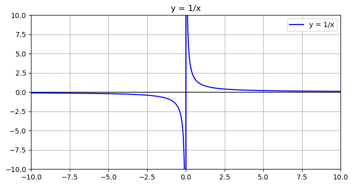

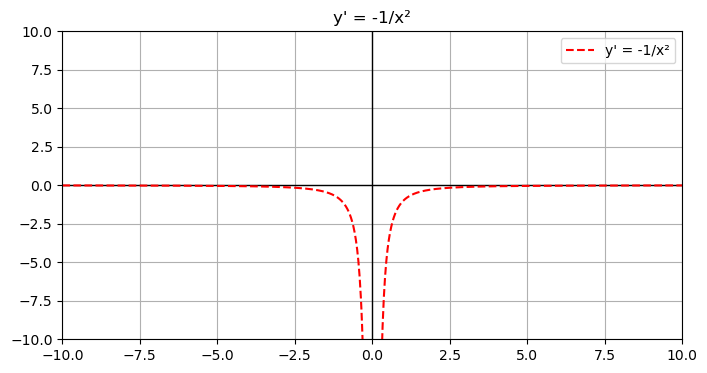

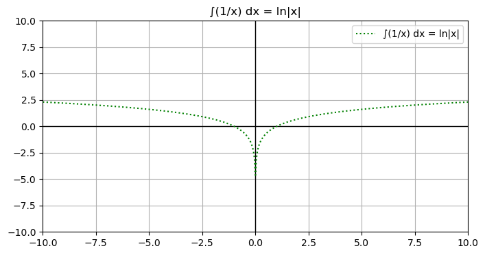

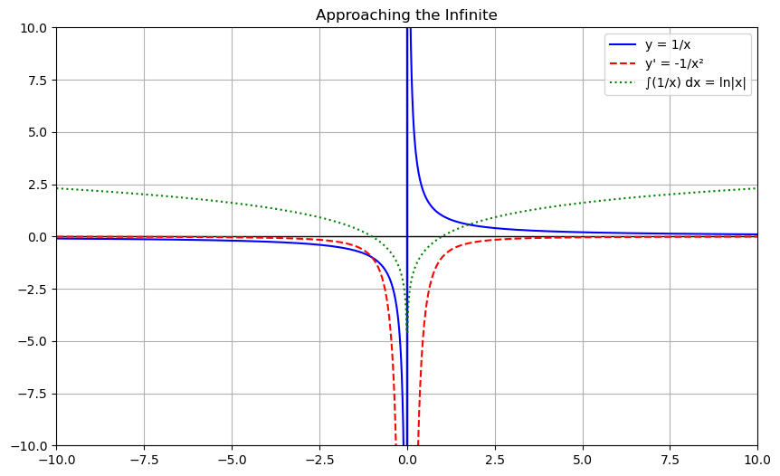

```python
import numpy as np
import matplotlib.pyplot as plt

# Define x values avoiding zero
x = np.linspace(-10, 10, 1000)
x = x[x != 0]

# Define the functions
y = 1 / x
y_prime = -1 / x**2
y_integral = np.log(np.abs(x))

# Plot y = 1/x
plt.figure(figsize=(8, 4))
plt.axhline(0, color='black', linewidth=1)
plt.axvline(0, color='black', linewidth=1)
plt.plot(x, y, label='y = 1/x', color='blue')
plt.ylim(-10, 10)
plt.xlim(-10, 10)
plt.title("y = 1/x")
plt.grid(True)
plt.legend()
plt.show()

# Plot y' = -1/x²
plt.figure(figsize=(8, 4))
plt.axhline(0, color='black', linewidth=1)
plt.axvline(0, color='black', linewidth=1)
plt.plot(x, y_prime, label="y' = -1/x²", color='red', linestyle='--')
plt.ylim(-10, 10)
plt.xlim(-10, 10)
plt.title("y' = -1/x²")
plt.grid(True)
plt.legend()
plt.show()

# Plot ∫(1/x) dx = ln|x|
plt.figure(figsize=(8, 4))
plt.axhline(0, color='black', linewidth=1)
plt.axvline(0, color='black', linewidth=1)
plt.plot(x, y_integral, label='∫(1/x) dx = ln|x|', color='green', linestyle=':')
plt.ylim(-10, 10)
plt.xlim(-10, 10)
plt.title("∫(1/x) dx = ln|x|")
plt.grid(True)
plt.legend()
plt.show()

import numpy as np
import matplotlib.pyplot as plt

x = np.linspace(-10, 10, 1000)
x = x[x != 0]
y = 1 / x
y_prime = -1 / x**2
y_integral = np.log(np.abs(x))

plt.figure(figsize=(10, 6))
plt.axhline(0, color='black', linewidth=1)
plt.axvline(0, color='black', linewidth=1)
plt.plot(x, y, label='y = 1/x', color='blue')
plt.plot(x, y_prime, label="y' = -1/x²", color='red', linestyle='--')
plt.plot(x, y_integral, label='∫(1/x) dx = ln|x|', color='green', linestyle=':')

plt.ylim(-10, 10)
plt.xlim(-10, 10)
plt.legend()
plt.title("Approaching the Infinite")
plt.grid(True)
plt.show()
```

↩️ Back to Table of Contents

## ✦ Addendum: The Ledger of Reflection — On Divine Compounding ✦

> **Bismillāh ar‑Raḥmān ar‑Raḥīm**  
> *He is the One who multiplies a single seed into seven ears, and in every ear a hundred grains.*  
> — Surah al-Baqarah (The Qur'an, 2:261)²⁰

From the age of twelve I tilled an inner field I could not yet name.  
I pressed one silent hour of wonder into the soil of every day,  
even while my tongue denied the Sower.  
So the unseen ledger began:

- **70 prayer‑seeds** sown each dawn of doubt.
- **Four harvest‑weeks** a year when the plough ran **thirteen hours** a day.
- **Five petals** plucked in “debt” wherever ritual fell silent.

By the time the sun of twenty‑five rose over my confession,  
the field had yielded **one million daily‑prayer equivalents**—  
an orchard grown *in spite* of me, not *because* of me.  
(How subtle is the Gardener, coaxing fruit from hands that prune their own blossoms!)

So I walk on—ledger in one hand, seeds in the other—  
certain that every quiet thought of God is already  
re‑invested in the architecture of my soul;  
and that on the Day all books are opened  
I will find a garden I never expected,  
wafting the fragrance of every question I once asked in the dark.

### 3 Lessons in Agronomy and Grace

1. **Intention is the true fertilizer.**  
   A dry seed of reflection, watered by *niyyah*, splits stone.
2. **Debits end where confession begins.**  
   The moment I named Him aloud, loss became impossible.
3. **Growth is exponential because mercy is exponential.**  
   The Gardener never counts one grain as one.

> *“And your Lord does not allow the reward of the mindful to be lost.”*  
> — Sūrat al-Hūd (The Qur'an, 11:115)²¹

> *“Then as for he who is given his record in his right hand,"*

> *"He will be judged with an easy reckoning.”*

> — Sūrat al-Inshiqāq (The Qur'an, 84:7–8)²²
20. https://quran.com/2/261
21. https://quran.com/11/115
22. https://quran.com/84/7-8

↩️ Back to Table of Contents

#### Below is the code I used to calculate the compound spiritual value of my years in silent remembrance. Not because God needs it — but because I did. I needed to see the shape of grace.

> *“A moment of reflection is worth seventy years of worship.”*

> — Imam Ali (ع), in ḥadīth

> *“Whoever does an atom’s weight of good will see it."*

> *"And whoever does an atom’s weight of harm will see it.”*

> — Surah al-Zalzalah (The Qur'an, 99:7–8)²³
23. https://quran.com/99/7-8

```python
# --- Part 1: Daily deposits over 13 years ---

daily_athiest_principle = 134.71594798  # Net daily principle deposits
annual_interest_rate = 0.07  # Annual interest rate (7%)
n = 365.25  # Days per year = compounding periods per year)
interest_per_day = annual_interest_rate / n  # Interest rate per day (0.0192%)
periods = 365.25 * 13  # Compounding periods per year times 13 years (4748.25 compounding days in 13 years, accounting for leap years)


# Future Value Calculations on a Per Day Basis
daily_future_value = daily_athiest_principle * ((1 + interest_per_day) ** periods - 1) / interest_per_day
print("Future value of daily contemplation (13 years):", daily_future_value)  # Prints output of the calculations to the console

# --- Part 2: Week-long spiritual review lump sum quarterly deposit compounded over 13 years ---

# 70 daily prayers-value per hour of divine contemplation,
# times 13 hours per day in dedicated study, ( = 910 daily prayers )
# times 7 days per quarterly spiritual review, ( = 6,370 daily prayers )
# times 4 quarters in a year, ( = 25,480 daily prayers )
# times 13 years (52 quarters). ( = 331240 daily prayers )

prayer_lump = 6370 # Daily prayer equivalents collected within 52 spiritual quarterly reviews over 13 years
num_lumps = 52 # 4 quarters per year, times 13 years = 52 principle deposits
interval = 365.25 / 4  # Days per quarterly deposit period per year
fv_lumps = 0  # Future-value var


for i in range(num_lumps):
    remaining = periods - int(round(interval * i))
    fv_lumps += prayer_lump * ((1 + interest_per_day) ** remaining)
print("Future value of quarterly reviews (13 years):", fv_lumps)
```

```
Future value of daily contemplation (13 years): 1043220.4655876334
Future value of quarterly reviews (13 years): 545007.7530081093
```

1,043,220.4656 (daily) + 545,007.7530 (quarterly) = 1,588,228 daily-value *Namaaz* prayers in 13 years of being an atheist or agnostic

Daily namaaz prayers normally accumlated in 13 years (5 times a day * 365.25 days per year * 13 years) = 23,741 daily *Namaaz* normally accrued in 13 years

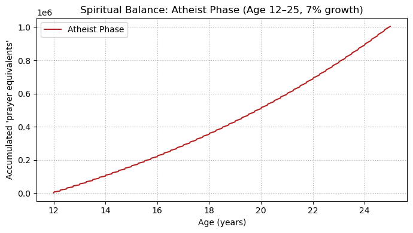

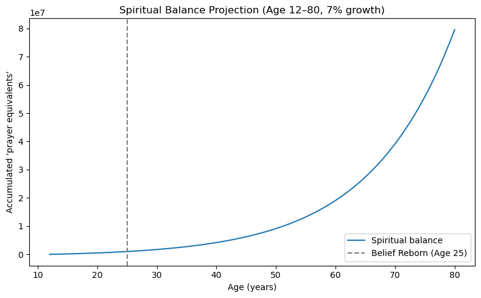

```python
# --- Part 3: Full lifespan curve (Age 12–80) ---
import matplotlib.pyplot as plt
import numpy as np

annual_rate = 0.07
r_daily = annual_rate / 365.0
start_age = 12
end_age = 80
days_total = int((end_age - start_age) * 365)

review_starts = [0, 91, 182, 273]
review_length = 7

balance_life = 0.0
balances_life = []
ages_life = []

for day in range(days_total):
    balance_life *= (1 + r_daily)
    age = start_age + day / 365.0
    day_of_year = day % 365
    in_review = any(start <= day_of_year < start + review_length for start in review_starts)
    deposit = 910 if in_review else 70
    net_deposit = deposit - 5 if age < 25 else deposit
    balance_life += net_deposit
    if day % 7 == 0:
        balances_life.append(balance_life)
        ages_life.append(age)

# --- Part 4: Zoom-in on atheist phase (Age 12–25) ---
balance_ath = 0.0
balances_ath = []
ages_ath = []
days_ath = int((25 - 12) * 365)

for day in range(days_ath):
    balance_ath *= (1 + r_daily)
    day_of_year = day % 365
    in_review = any(start <= day_of_year < start + review_length for start in review_starts)
    deposit = 910 if in_review else 70
    net_deposit = deposit - 5
    balance_ath += net_deposit
    if day % 7 == 0:
        balances_ath.append(balance_ath)
        ages_ath.append(12 + day / 365.0)

# --- Plot atheist phase zoom-in ---
plt.figure(figsize=(7,4))
plt.plot(ages_ath, balances_ath, color="firebrick", label="Atheist Phase")
plt.xlabel("Age (years)")
plt.ylabel("Accumulated 'prayer equivalents'")
plt.title("Spiritual Balance: Atheist Phase (Age 12–25, 7% growth)")
plt.grid(True, linestyle=":")
plt.legend()
plt.tight_layout()
plt.show()

# --- Plot full lifespan projection ---
plt.figure(figsize=(8,5))
plt.plot(ages_life, balances_life, label="Spiritual balance")
plt.axvline(x=25, linestyle='--', color='gray', label="Belief Reborn (Age 25)")
plt.xlabel("Age (years)")
plt.ylabel("Accumulated 'prayer equivalents'")
plt.title("Spiritual Balance Projection (Age 12–80, 7% growth)")
plt.legend()
plt.tight_layout()
plt.show()
```

> *“It is He who sends down rain from the sky — "*

> *"And from it you drink, and from it grows vegetation on which you feed your herds."*

> *"He causes crops to flourish, with olives, palm trees, grapevines, and every kind of fruit."*

> *"Surely in this is a sign for people who reflect.”*

> — Surah al-Nahl (The Qur'an, 16:10–13)²⁴

> *“Whatever good you send forth for yourselves, you will find it with God — better and greater in reward.”*

> — Surah al-Muzzammil (The Qur'an, 73:20)²⁵
24. https://quran.com/16/10-13
25. https://quran.com/73/20

↩️ Back to Table of Contents

## 📐 Interlude 1/3 — On Large Numbers and the Logic of Wonder

There are numbers too heavy to dismiss. Magnitudes too patient to be random. Ratios so exact that they feel less like coincidence — and more like memory.

In 1937, physicist Paul Dirac noticed something: the strength of gravity compared to the other forces, the number of atoms in the observable universe, and the age of the cosmos measured in atomic time — were not just big numbers. They were woven numbers. Threads in a fabric that whispered one thing: This could not have been an accident.

Not infinite — but approaching meaning. Like a curve bending closer to an unseen axis.

And he wondered:

> "Is this coincidence?"

> "Or was it left behind by the Architect?"

This isn’t numerology. This isn’t certainty.

This is awe dressed in mathematics. This is longing written in the units of creation. This is what it means for numbers themselves to remember something sacred.

On the next page, you’ll glimpse what Dirac glimpsed — the quiet, cumulative symmetries hidden in cosmic forces, pointing not to proof, but to poetry.

Not to conclusion — but to invitation.

To remember that sometimes, even a number can become an āyah. A sign left fluttering at the edge of understanding.

```python
from IPython.display import IFrame

# Replace with your filename (must be in the same folder as the .ipynb)
IFrame("Dirac_large_numbers_hypothesis.pdf", width="100%", height=600)
```

[interactive chart not shown]

↩️ Back to Table of Contents

## ♟ Interlude 2/3 — On Choice, Chaos, and the Pattern Hidden in the Game

There are more ways to play a game of chess than there are atoms in the known universe. Roughly 10¹²⁰ possibilities — including even the illegal moves.

Each game is a path. Each move is a choice. Each choice creates a different universe.

Claude Shannon didn't just calculate a number. He uncovered a memory:

You will never brute-force meaning. You will never find your way by trying every door. You must feel the pattern underneath the chaos. You must listen for the mercy hidden beneath the moves.

We are not so different from chessboards. We are not so different from algorithms trembling with possibility. Each morning we wake — surrounded by 10¹²⁰ choices — and God, in His mercy, still lets us make just one.

Sometimes I wonder: maybe prayer is the moment when I stop calculating and simply remember the pattern I was born from.

What comes next is not a math lesson. It is an echo.

A reverent glance at the combinatorics of creation — a number so vast, it bends the back toward awe.

And beyond even that number?

One move. One mercy. One whisper of God saying:

Choose well.

```python
from IPython.display import IFrame

# Replace with your filename (must be in the same folder as the .ipynb)
IFrame("Shannon_number.pdf", width="100%", height=600)
```

[interactive chart not shown]

↩️ Back to Table of Contents

## 🧠 Interlude 3/3 — On Thought, Fractals, and the Sacred Order of Chaos

I have seen what thought looks like when it shatters.

When the mind trembles under the weight of too many questions.

When even memory falls apart like dust on a trembling page.

And yet —

somewhere inside the wreckage —

the mind begins again.

It learns how to carry the question differently.

Not through clarity.

Not through answers.

But through pattern.

Through rhythm.

There is a science to this. A hidden geometry of survival.

The EEG doesn't just trace brainwaves — it maps a soul trying to remember itself in real time.

Mathematicians call it the Hurst exponent.

Scientists call it fractal time series analysis.

But I call it something simpler:

the memory of God, hidden inside confusion.

Because even in chaos,

the mind leans toward order.

The heart leans toward realignment.

The soul leans toward return.

It curves.

It bends.

It shapes itself around the unseen axis of Mercy.

It wants to solve the puzzle — and become a sign.

What you’re about to see is not just a scientific paper. It is sacred evidence.

Proof that even broken thought is still reaching. Still praying.

Still remembering.

```python
from IPython.display import IFrame

# Replace with your filename (must be in the same folder as the .ipynb)
IFrame("Neurological_Order_and_Chaos.pdf", width="100%", height=600)
```

[interactive chart not shown]

↩️ Back to Table of Contents

## Appendix: A Note to the Scientific Reader

This book was not written to prove.

It was written to remember.

Still, if you have come here with the questions of a scientist, you are welcome — this was also written for you (as it was for me).

You have already seen Dirac’s dimensionless large numbers,

Shannon’s combinatoric scale,

the EEG rhythms of order and chaos,

the inverse curves and logarithmic devotions of calculus,

The divine ledger.

These were not illustrations.

They were invitations.

I believe the mind, like the universe, is sacred not because it is solved — but because it longs to be understood.

I believe the role of science is not to strip the soul from nature, but to show us how deeply soul is embedded in structure. In scale. In pattern. In noise. In complexity.

If you are a researcher:

> May your data become duʿā.

> May your calculations bow in awe.

> May your pursuit of knowledge be a form of remembering Him.

↩️ Back to Table of Contents

```python
from IPython.display import IFrame

# Replace with your filename (must be in the same folder as the .ipynb)
IFrame("Cover.pdf", width="100%", height=600)
```

[interactive chart not shown]

↩️ Back to Table of Contents

## ✨ The Quadrants of God

| Quadrant | Symbolic Meaning |
| --- | --- |
| Top Right *(Forwards)* | Divine clarity, revelation, original perception |
| Top Left *(Backwards)* | Reflection, introspection, rediscovery of origin |
| Bottom Right *(Upside-Down)* | Chaos, testing, understanding God through struggle |
| Bottom Left *(Both Flips)* | Ego death, rebirth, surrender into unity |

↩️ Back to Table of Contents

## 🔁 Mirroring the Divine

**When we learn a new language or script, we don’t just decode letters — we mirror the worldview that created them.**

And God, in all mirrored forms, still remains God.

*In every orientation — upright, reversed, or inverted — the message of oneness echoes back to you.*

↩️ Back to Table of Contents